# PartIIIC

Hua Ji

4/25/2022

# Load packages

The `tidyverse` and `caret` packages are loaded below.

```r
library(tidyverse)
library(caret)
```

## Read and prepare data

```r
df_all <- readr::read_csv("final_project_train.csv", col_names = TRUE)
df_all %>%glimpse()
```

```
## Rows: 677
## Columns: 38
## $ rowid    <dbl> 1, 3, 4, 5, 8, 9, 11, 14, 15, 16, 17, 18, 19, 22, 24, 25, 27,…
## $ region   <chr> "XX", "XX", "XX", "XX", "XX", "XX", "XX", "XX", "XX", "XX", "…
## $ customer <chr> "B", "B", "B", "B", "B", "B", "B", "B", "B", "B", "B", "B", "…
## $ xb_01    <dbl> 4.000000, 1.000000, 2.000000, 2.520000, 2.548387, 3.071429, 3…
## $ xb_02    <dbl> 4, 1, 2, 11, 6, 6, 10, 12, 9, 10, 8, 10, 10, 8, 6, 10, 13, 10…
## $ xb_03    <dbl> 4, 1, 2, -6, -1, 1, -4, -4, -2, -4, -2, -2, -2, -4, 1, -4, -3…
## $ xn_01    <dbl> 3.0000000, 2.0000000, 2.0000000, 1.5333333, 0.8387097, 1.8571…
## $ xn_02    <dbl> 3, 2, 4, 9, 3, 8, 6, 10, 10, 4, 6, 8, 9, 5, 7, 12, 12, 6, 6, …
## $ xn_03    <dbl> 3, 2, 0, -3, -4, -2, -5, -6, -3, -5, -3, -6, -4, -3, 0, -5, -…
## $ xa_01    <dbl> 12.000000, 3.000000, 9.000000, 7.080000, 6.451613, 6.857143, …
## $ xa_02    <dbl> 12, 3, 9, 29, 17, 18, 24, 27, 20, 19, 15, 24, 24, 15, 14, 26,…
## $ xa_03    <dbl> 12, 3, 9, -7, -2, 2, -9, -5, -3, -3, -1, 1, -2, -3, 3, -4, -5…
## $ xb_04    <dbl> 1.3333333, 1.0000000, 1.0000000, 0.8950476, 1.2247312, 1.1857…
```

[output cut: 25 more lines]

```r
pf_all<-df_all %>% mutate(y=ifelse(outcome=="event",1,0))%>%select(!c(rowid,response,outcome))
pf_all
```

```
## # A tibble: 677 × 36
##    region customer xb_01 xb_02 xb_03 xn_01 xn_02 xn_03 xa_01 xa_02 xa_03 xb_04
##    <chr>  <chr>    <dbl> <dbl> <dbl> <dbl> <dbl> <dbl> <dbl> <dbl> <dbl> <dbl>
##  1 XX     B         4        4     4 3         3     3 12       12    12 1.33
##  2 XX     B         1        1     1 2         2     2  3        3     3 1
##  3 XX     B         2        2     2 2         4     0  9        9     9 1
##  4 XX     B         2.52    11    -6 1.53      9    -3  7.08    29    -7 0.895
##  5 XX     B         2.55     6    -1 0.839     3    -4  6.45    17    -2 1.22
##  6 XX     B         3.07     6     1 1.86      8    -2  6.86    18     2 1.19
##  7 XX     B         3.09    10    -4 1.51      6    -5  7.66    24    -9 1.03
##  8 XX     B         3.71    12    -4 1.59     10    -6  8.16    27    -5 1.27
##  9 XX     B         2.70     9    -2 1.17     10    -3  6.89    20    -3 0.906
## 10 XX     B         2.82    10    -4 1.02      4    -5  7.14    19    -3 0.945
## # … with 667 more rows, and 24 more variables: xb_05 <dbl>, xb_06 <dbl>,
## #   xb_07 <dbl>, xb_08 <dbl>, xn_04 <dbl>, xn_05 <dbl>, xn_06 <dbl>,
## #   xn_07 <dbl>, xn_08 <dbl>, xa_04 <dbl>, xa_05 <dbl>, xa_06 <dbl>,
## #   xa_07 <dbl>, xa_08 <dbl>, xw_01 <dbl>, xw_02 <dbl>, xw_03 <dbl>,
## #   xs_01 <dbl>, xs_02 <dbl>, xs_03 <dbl>, xs_04 <dbl>, xs_05 <dbl>,
## #   xs_06 <dbl>, y <dbl>
```

```r
library(rstanarm)
mod3_Bayesian <-stan_glm(y~.,data =pf_all,
                             family = binomial(link = "logit"),
                             prior_intercept = normal(0, 1, autoscale = TRUE),
                             prior = normal(0, 1, autoscale = TRUE),
                             seed = 12345)
mod4_Bayesian <-stan_glm(y~ region * (.-region),
                         data = pf_all %>% select(!c( "customer")),
                         family = binomial(link = "logit"),
                         prior_intercept = normal(0, 1, autoscale = TRUE),
                         prior = normal(0, 1, autoscale = TRUE),
                         seed = 12345)
```

```r
viz_grid <- expand.grid(xn_07 =seq(-3.2,3.2,length.out=101),
                        xb_07 =seq(-3,3, length.out=6),
                        xb_04=0,
                        xb_01=0,
                        xb_02=0,
                        xb_03=0,
                        xb_05=0,
                        xb_06=0,
                        xb_08=0,
                        xn_01=0,
                        xn_02=0,
                        xn_03=0,
                        xn_04=0,
                        xn_05=0,
                        xn_06=0,
                        xn_08=0,
                        xa_01=0,
                        xa_02=0,
                        xa_03=0,
                        xa_04=0,
                        xa_05=0,
                        xa_06=0,
                        xa_07=0,
                        xa_08=0,
                        xw_01=0,
                        xw_02=0,
                        xw_03=0,
                        xs_01=0,
                        xs_02=0,
                        xs_03=0,
                        xs_04=0,
                        xs_05=0,
                        xs_06=0,
                        region="XX",
                        customer="A",
                        KEEP.OUT.ATTRS = FALSE,
                        stringsAsFactors = FALSE) %>%
  as.data.frame() %>% tibble::as_tibble()
viz_grid%>%glimpse()
```

```
## Rows: 606
## Columns: 35
## $ xn_07    <dbl> -3.200, -3.136, -3.072, -3.008, -2.944, -2.880, -2.816, -2.75…
## $ xb_07    <dbl> -3, -3, -3, -3, -3, -3, -3, -3, -3, -3, -3, -3, -3, -3, -3, -…
## $ xb_04    <dbl> 0, 0, 0, 0, 0, 0, 0, 0, 0, 0, 0, 0, 0, 0, 0, 0, 0, 0, 0, 0, 0…
## $ xb_01    <dbl> 0, 0, 0, 0, 0, 0, 0, 0, 0, 0, 0, 0, 0, 0, 0, 0, 0, 0, 0, 0, 0…
## $ xb_02    <dbl> 0, 0, 0, 0, 0, 0, 0, 0, 0, 0, 0, 0, 0, 0, 0, 0, 0, 0, 0, 0, 0…
## $ xb_03    <dbl> 0, 0, 0, 0, 0, 0, 0, 0, 0, 0, 0, 0, 0, 0, 0, 0, 0, 0, 0, 0, 0…
## $ xb_05    <dbl> 0, 0, 0, 0, 0, 0, 0, 0, 0, 0, 0, 0, 0, 0, 0, 0, 0, 0, 0, 0, 0…
## $ xb_06    <dbl> 0, 0, 0, 0, 0, 0, 0, 0, 0, 0, 0, 0, 0, 0, 0, 0, 0, 0, 0, 0, 0…
## $ xb_08    <dbl> 0, 0, 0, 0, 0, 0, 0, 0, 0, 0, 0, 0, 0, 0, 0, 0, 0, 0, 0, 0, 0…
## $ xn_01    <dbl> 0, 0, 0, 0, 0, 0, 0, 0, 0, 0, 0, 0, 0, 0, 0, 0, 0, 0, 0, 0, 0…
## $ xn_02    <dbl> 0, 0, 0, 0, 0, 0, 0, 0, 0, 0, 0, 0, 0, 0, 0, 0, 0, 0, 0, 0, 0…
## $ xn_03    <dbl> 0, 0, 0, 0, 0, 0, 0, 0, 0, 0, 0, 0, 0, 0, 0, 0, 0, 0, 0, 0, 0…
## $ xn_04    <dbl> 0, 0, 0, 0, 0, 0, 0, 0, 0, 0, 0, 0, 0, 0, 0, 0, 0, 0, 0, 0, 0…
```

[output cut: 22 more lines]

```r
posterior_linpred(mod3_Bayesian, newdata = viz_grid)%>%dim()
```

```
## [1] 4000  606
```

The posterior predictive uncertainty is represented by ribbons displaying the posterior 90% uncertainty interval on the mean trend. In lecture we referred to this as the confidence interval on the mean.

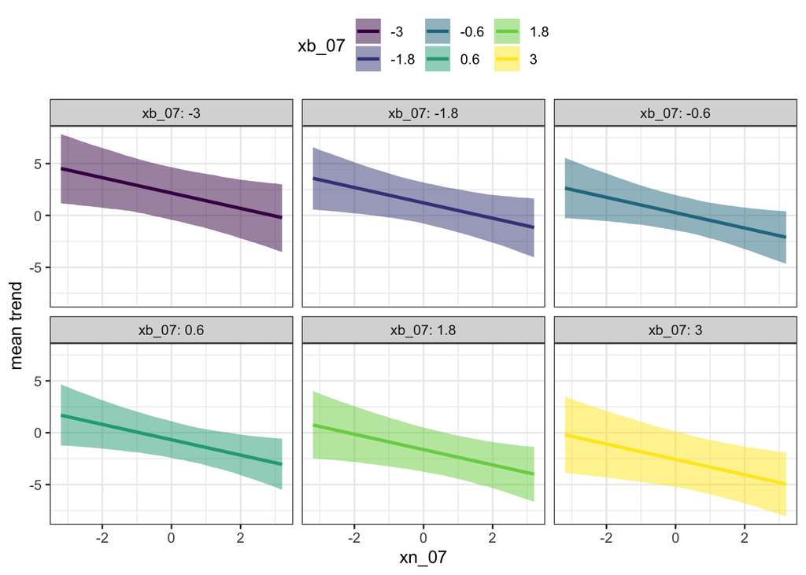

```r
posterior_linpred(mod3_Bayesian, newdata = viz_grid) %>%
  as.data.frame() %>% tibble::as_tibble() %>%
  tibble::rowid_to_column("post_id") %>%
  pivot_longer(!c("post_id"), names_to = 'pred_id') %>%
  mutate(across(.cols = 'pred_id', .fns = as.numeric)) %>%
  group_by(pred_id) %>%
  summarise(num_post = n(),
            trend_avg = mean(value),
            trend_lwr = quantile(value, 0.05),
            trend_upr = quantile(value, 0.95)) %>%
  ungroup() %>%
  left_join(viz_grid %>% tibble::rowid_to_column("pred_id"),
            by = "pred_id") %>%
  ggplot(mapping = aes(x = xn_07)) +
  geom_ribbon(mapping = aes(ymin = trend_lwr,
                            ymax = trend_upr,
                            fill = as.factor(xb_07)),
              alpha = 0.5) +
  geom_line(mapping = aes(y = trend_avg,
                          color = as.factor(xb_07)),
                size = 1.) +
  facet_wrap(~xb_07, labeller = "label_both") +
  scale_fill_viridis_d("xb_07") +
  scale_color_viridis_d("xb_07") +
  labs(y = "mean trend") +
  theme_bw() +
  theme(legend.position = "top")
```

According to the above figures, it was obviously seen that the mean trend linearly decreased with the input xn_07. Also we can see that the mean trend decreased when we increased the variable xb_07. The xn_07 and xb_07 variables are the additive effect on the mean trend.

```r
posterior_linpred(mod4_Bayesian, newdata = viz_grid)%>%dim()
```

```
## [1] 4000  606
```

The posterior predictive uncertainty is represented by ribbons displaying the posterior 90% uncertainty interval on the mean trend. In lecture we referred to this as the confidence interval on the mean.

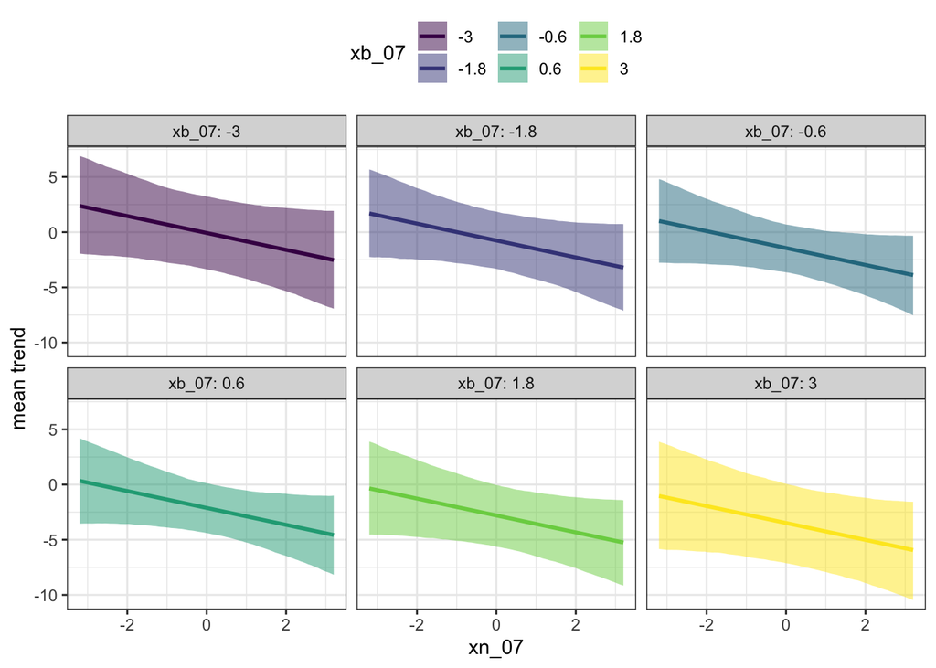

```r
posterior_linpred(mod4_Bayesian, newdata = viz_grid) %>%
  as.data.frame() %>% tibble::as_tibble() %>%
  tibble::rowid_to_column("post_id") %>%
  pivot_longer(!c("post_id"), names_to = 'pred_id') %>%
  mutate(across(.cols = 'pred_id', .fns = as.numeric)) %>%
  group_by(pred_id) %>%
  summarise(num_post = n(),
            trend_avg = mean(value),
            trend_lwr = quantile(value, 0.05),
            trend_upr = quantile(value, 0.95)) %>%
  ungroup() %>%
  left_join(viz_grid %>% tibble::rowid_to_column("pred_id"),
            by = "pred_id") %>%
  ggplot(mapping = aes(x = xn_07)) +
  geom_ribbon(mapping = aes(ymin = trend_lwr,
                            ymax = trend_upr,
                            fill = as.factor(xb_07)),
              alpha = 0.5) +
  geom_line(mapping = aes(y = trend_avg,
                          color = as.factor(xb_07)),
                size = 1.) +
  facet_wrap(~xb_07, labeller = "label_both") +
  scale_fill_viridis_d("xb_07") +
  scale_color_viridis_d("xb_07") +
  labs(y = "mean trend") +
  theme_bw() +
  theme(legend.position = "top")
```

The predictive trends of the two models are consistent, their mean trends decrease with the increase of the input variables.